# 🌙 Sleep Health & Lifestyle — Exploratory Data Analysis

> **Dataset:** 374 individuals · 13 variables  
> **Purpose:** Uncover how stress, BMI, occupation, and physical activity shape sleep quality and disorder prevalence.  
> **Platform:** Google Colab · Python 3

## 📦 1. Setup & Imports

```python
# Install any extra deps (most are pre-installed on Colab)
!pip install -q kaggle

import pandas as pd
import numpy as np
from matplotlib.colors import LinearSegmentedColormap
import matplotlib.pyplot as plt
import matplotlib.patches as mpatches
import matplotlib.ticker as mticker
import seaborn as sns
from scipy import stats
import warnings
warnings.filterwarnings('ignore')

# ── Dark theme ──
plt.rcParams.update({
    'figure.facecolor': '#0e1117',
    'axes.facecolor':   '#161b27',
    'axes.edgecolor':   '#2e3a52',
    'axes.labelcolor':  '#c0cce8',
    'axes.titlecolor':  '#e2e8f8',
    'axes.titlesize':   13,
    'axes.labelsize':   11,
    'xtick.color':      '#7a89b0',
    'ytick.color':      '#7a89b0',
    'xtick.labelsize':  9,
    'ytick.labelsize':  9,
    'grid.color':       '#252d45',
    'grid.linewidth':   0.6,
    'text.color':       '#e2e8f8',
    'legend.facecolor': '#161b27',
    'legend.edgecolor': '#2e3a52',
    'legend.fontsize':  9,
    'figure.dpi':       120,
    'font.family':      'monospace',
})

PALETTE = {
    'None':        '#6c8bef',
    'Sleep Apnea': '#ef6c8b',
    'Insomnia':    '#efcb6c',
    'Normal':      '#6cef9f',
    'Overweight':  '#ef9f6c',
    'Obese':       '#ef6c6c',
    'Male':        '#6c8bef',
    'Female':      '#ef6c8b',
}

print("✅ Setup complete.")
```

```
✅ Setup complete.
```

## 📂 2. Load Dataset

Upload the CSV file when prompted, or mount Google Drive if the file is already there.

```python
from google.colab import files


from google.colab import drive
drive.mount('/content/drive')
df_raw = pd.read_csv('/content/drive/MyDrive/AIML/Great Learning/Sleep_health_and_lifestyle_dataset.csv')

print(f"Loaded: {df_raw.shape[0]} rows × {df_raw.shape[1]} columns")
df_raw.head()
```

```
Loaded: 374 rows × 13 columns
```

|  | Person ID | Gender | Age | Occupation | Sleep Duration | Quality of Sleep | Physical Activity Level | Stress Level | BMI Category | Blood Pressure | Heart Rate | Daily Steps | Sleep Disorder |
| --- | --- | --- | --- | --- | --- | --- | --- | --- | --- | --- | --- | --- | --- |
| 0 | 1 | Male | 27 | Software Engineer | 6.1 | 6 | 42 | 6 | Overweight | 126/83 | 77 | 4200 | NaN |
| 1 | 2 | Male | 28 | Doctor | 6.2 | 6 | 60 | 8 | Normal | 125/80 | 75 | 10000 | NaN |
| 2 | 3 | Male | 28 | Doctor | 6.2 | 6 | 60 | 8 | Normal | 125/80 | 75 | 10000 | NaN |
| 3 | 4 | Male | 28 | Sales Representative | 5.9 | 4 | 30 | 8 | Obese | 140/90 | 85 | 3000 | Sleep Apnea |
| 4 | 5 | Male | 28 | Sales Representative | 5.9 | 4 | 30 | 8 | Obese | 140/90 | 85 | 3000 | Sleep Apnea |

## 🧹 3. Data Cleaning & Feature Engineering

```python
df = df_raw.copy()

# 1. Standardise BMI: merge 'Normal Weight' → 'Normal'
df['BMI Category'] = df['BMI Category'].replace('Normal Weight', 'Normal')

# 2. Fill NaN Sleep Disorder → 'None' (means no disorder detected)
df['Sleep Disorder'] = df['Sleep Disorder'].fillna('None')

# 3. Parse Blood Pressure "120/80" → two numeric columns
df[['BP_Systolic', 'BP_Diastolic']] = (
    df['Blood Pressure'].str.split('/', expand=True).astype(int)
)

# 4. Drop raw BP string & Person ID (not analytical)
df.drop(columns=['Blood Pressure', 'Person ID'], inplace=True)

# 5. Ordered categoricals
bmi_order    = ['Normal', 'Overweight', 'Obese']
stress_order = sorted(df['Stress Level'].unique())

df['BMI Category'] = pd.Categorical(df['BMI Category'], categories=bmi_order, ordered=True)

print("✅ Cleaning complete.")
print(f"Shape: {df.shape}")
df.dtypes
```

```
✅ Cleaning complete.
Shape: (374, 13)
```

|  | 0 |
| --- | --- |
| Gender | object |
| Age | int64 |
| Occupation | object |
| Sleep Duration | float64 |
| Quality of Sleep | int64 |
| Physical Activity Level | int64 |
| Stress Level | int64 |
| BMI Category | category |
| Heart Rate | int64 |
| Daily Steps | int64 |
| Sleep Disorder | object |
| BP_Systolic | int64 |
| BP_Diastolic | int64 |

**dtype:** object

## 🔍 4. Dataset Overview

```python
print("=" * 55)
print("  SLEEP HEALTH DATASET — QUICK PROFILE")
print("=" * 55)
print(f"  Rows            : {len(df)}")
print(f"  Columns         : {df.shape[1]}")
print(f"  Missing values  : {df.isnull().sum().sum()}")
print()
print("  NUMERIC SUMMARY")
print("-" * 55)
display(df.describe().round(2))

print()
print("  CATEGORICAL COUNTS")
print("-" * 55)
for col in ['Gender', 'Occupation', 'BMI Category', 'Sleep Disorder']:
    print(f"\n  {col}:")
    for val, cnt in df[col].value_counts().items():
        pct = cnt / len(df) * 100
        bar = '█' * int(pct / 3)
        print(f"    {val:<20} {cnt:>3}  ({pct:5.1f}%)  {bar}")
```

```
=======================================================
  SLEEP HEALTH DATASET — QUICK PROFILE
=======================================================
  Rows            : 374
  Columns         : 13
  Missing values  : 0

  NUMERIC SUMMARY
-------------------------------------------------------
```

|  | Age | Sleep Duration | Quality of Sleep | Physical Activity Level | Stress Level | Heart Rate | Daily Steps | BP_Systolic | BP_Diastolic |
| --- | --- | --- | --- | --- | --- | --- | --- | --- | --- |
| count | 374.00 | 374.00 | 374.00 | 374.00 | 374.00 | 374.00 | 374.00 | 374.00 | 374.00 |
| mean | 42.18 | 7.13 | 7.31 | 59.17 | 5.39 | 70.17 | 6816.84 | 128.55 | 84.65 |
| std | 8.67 | 0.80 | 1.20 | 20.83 | 1.77 | 4.14 | 1617.92 | 7.75 | 6.16 |
| min | 27.00 | 5.80 | 4.00 | 30.00 | 3.00 | 65.00 | 3000.00 | 115.00 | 75.00 |
| 25% | 35.25 | 6.40 | 6.00 | 45.00 | 4.00 | 68.00 | 5600.00 | 125.00 | 80.00 |
| 50% | 43.00 | 7.20 | 7.00 | 60.00 | 5.00 | 70.00 | 7000.00 | 130.00 | 85.00 |
| 75% | 50.00 | 7.80 | 8.00 | 75.00 | 7.00 | 72.00 | 8000.00 | 135.00 | 90.00 |
| max | 59.00 | 8.50 | 9.00 | 90.00 | 8.00 | 86.00 | 10000.00 | 142.00 | 95.00 |

```
  CATEGORICAL COUNTS
-------------------------------------------------------

  Gender:
    Male                 189  ( 50.5%)  ████████████████
    Female               185  ( 49.5%)  ████████████████

  Occupation:
    Nurse                 73  ( 19.5%)  ██████
    Doctor                71  ( 19.0%)  ██████
    Engineer              63  ( 16.8%)  █████
    Lawyer                47  ( 12.6%)  ████
    Teacher               40  ( 10.7%)  ███
    Accountant            37  (  9.9%)  ███
    Salesperson           32  (  8.6%)  ██
    Scientist              4  (  1.1%)
    Software Engineer      4  (  1.1%)
    Sales Representative   2  (  0.5%)
    Manager                1  (  0.3%)

  BMI Category:
    Normal               216  ( 57.8%)  ███████████████████
    Overweight           148  ( 39.6%)  █████████████
    Obese                 10  (  2.7%)

  Sleep Disorder:
    None                 219  ( 58.6%)  ███████████████████
    Sleep Apnea           78  ( 20.9%)  ██████
    Insomnia              77  ( 20.6%)  ██████
```

## 📊 5. Univariate Distributions

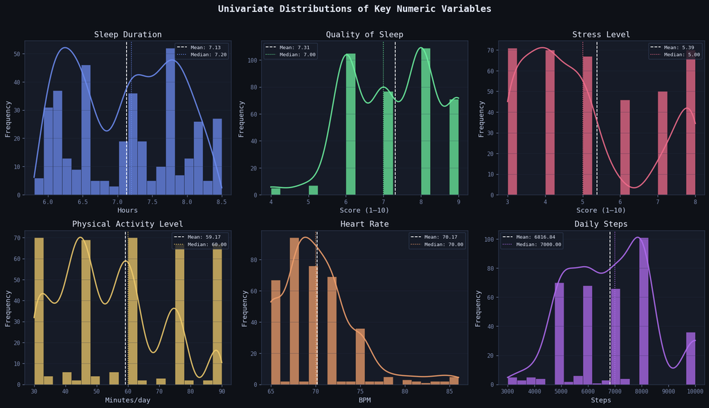

```python
fig, axes = plt.subplots(2, 3, figsize=(16, 9))
fig.suptitle('Univariate Distributions of Key Numeric Variables',
             fontsize=15, fontweight='bold', color='#e2e8f8', y=1.01)

num_cols = [
    ('Sleep Duration',          '#6c8bef', 'Hours'),
    ('Quality of Sleep',        '#6cef9f', 'Score (1–10)'),
    ('Stress Level',            '#ef6c8b', 'Score (1–10)'),
    ('Physical Activity Level', '#efcb6c', 'Minutes/day'),
    ('Heart Rate',              '#ef9f6c', 'BPM'),
    ('Daily Steps',             '#b06cef', 'Steps'),
]

for ax, (col, color, xlabel) in zip(axes.flat, num_cols):
    data = df[col]
    ax.hist(data, bins=20, color=color, alpha=0.75, edgecolor='#0e1117', linewidth=0.5)

    # Overlay KDE
    kde_x = np.linspace(data.min(), data.max(), 200)
    kde   = stats.gaussian_kde(data)
    ax2   = ax.twinx()
    ax2.plot(kde_x, kde(kde_x), color=color, linewidth=2, alpha=0.9)
    ax2.set_yticks([])
    ax2.set_facecolor('none')
    for spine in ax2.spines.values(): spine.set_visible(False)

    # Stats annotation
    ax.axvline(data.mean(),   color='white',  linestyle='--', linewidth=1.2, label=f'Mean: {data.mean():.2f}')
    ax.axvline(data.median(), color=color,    linestyle=':',  linewidth=1.2, label=f'Median: {data.median():.2f}')
    ax.set_title(col)
    ax.set_xlabel(xlabel)
    ax.set_ylabel('Frequency')
    ax.legend(fontsize=8)
    ax.grid(axis='y', alpha=0.4)

plt.tight_layout()
plt.show()
```

## 🥧 6. Sleep Disorder Prevalence & Demographics

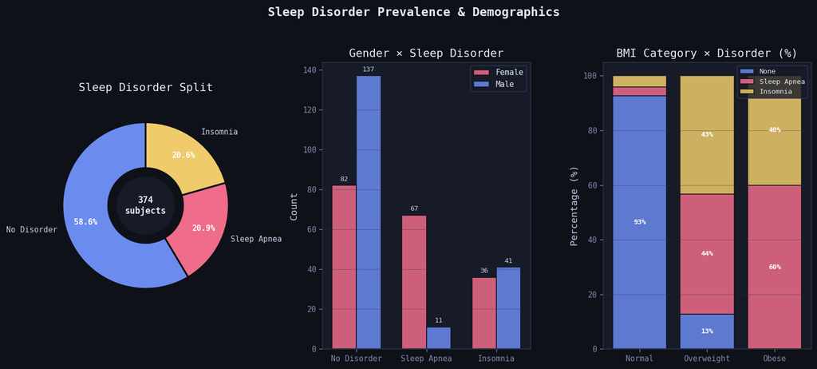

```python
fig = plt.figure(figsize=(16, 6))
gs  = fig.add_gridspec(1, 3, wspace=0.35)
fig.patch.set_facecolor('#0e1117')

disorder_colors = [PALETTE['None'], PALETTE['Sleep Apnea'], PALETTE['Insomnia']]
disorder_labels = ['No Disorder', 'Sleep Apnea', 'Insomnia']
disorder_counts = df['Sleep Disorder'].value_counts()[['None','Sleep Apnea','Insomnia']].values

# ── Donut ──
ax1 = fig.add_subplot(gs[0])
wedges, texts, autotexts = ax1.pie(
    disorder_counts,
    labels=disorder_labels,
    colors=disorder_colors,
    autopct='%1.1f%%',
    startangle=90,
    pctdistance=0.75,
    wedgeprops=dict(width=0.55, edgecolor='#0e1117', linewidth=2)
)
for t in texts:     t.set_color('#c0cce8'); t.set_fontsize(9)
for t in autotexts: t.set_color('white');   t.set_fontweight('bold'); t.set_fontsize(9)
centre = plt.Circle((0,0), 0.35, fc='#161b27')
ax1.add_patch(centre)
ax1.text(0, 0, f"{len(df)}\nsubjects", ha='center', va='center',
         fontsize=10, color='#e2e8f8', fontweight='bold')
ax1.set_title('Sleep Disorder Split', pad=12)

# ── Gender × Disorder grouped bar ──
ax2 = fig.add_subplot(gs[1])
gd = df.groupby(['Sleep Disorder', 'Gender']).size().unstack(fill_value=0)
gd = gd.loc[['None','Sleep Apnea','Insomnia']]
x  = np.arange(len(gd))
w  = 0.35
b1 = ax2.bar(x - w/2, gd['Female'], w, color=PALETTE['Female'], alpha=0.85,
             label='Female', edgecolor='#0e1117')
b2 = ax2.bar(x + w/2, gd['Male'],   w, color=PALETTE['Male'],   alpha=0.85,
             label='Male',   edgecolor='#0e1117')
ax2.set_xticks(x)
ax2.set_xticklabels(['No Disorder', 'Sleep Apnea', 'Insomnia'])
ax2.set_ylabel('Count')
ax2.set_title('Gender × Sleep Disorder')
ax2.legend()
ax2.grid(axis='y', alpha=0.4)
for bar in list(b1) + list(b2):
    h = bar.get_height()
    ax2.text(bar.get_x() + bar.get_width()/2, h + 1.5, str(int(h)),
             ha='center', va='bottom', fontsize=8, color='#c0cce8')

# ── BMI × Disorder stacked ──
ax3 = fig.add_subplot(gs[2])
bmi_d = df.groupby(['BMI Category','Sleep Disorder']).size().unstack(fill_value=0)
bmi_d = bmi_d.reindex(['Normal','Overweight','Obese'])
bmi_pct = bmi_d.div(bmi_d.sum(axis=1), axis=0) * 100
bottom = np.zeros(len(bmi_pct))
for disorder, color in zip(['None','Sleep Apnea','Insomnia'], disorder_colors):
    if disorder in bmi_pct.columns:
        vals = bmi_pct[disorder].values
        bars = ax3.bar(bmi_pct.index, vals, bottom=bottom, color=color,
                       alpha=0.85, edgecolor='#0e1117', label=disorder)
        for i, (b, v) in enumerate(zip(bottom, vals)):
            if v > 6:
                ax3.text(i, b + v/2, f'{v:.0f}%', ha='center', va='center',
                         fontsize=8, color='white', fontweight='bold')
        bottom += vals
ax3.set_ylabel('Percentage (%)')
ax3.set_title('BMI Category × Disorder (%)')
ax3.legend(loc='upper right', fontsize=8)
ax3.grid(axis='y', alpha=0.4)

plt.suptitle('Sleep Disorder Prevalence & Demographics', fontsize=14,
             fontweight='bold', color='#e2e8f8', y=1.03)
plt.show()
```

## 💼 7. Occupation Analysis

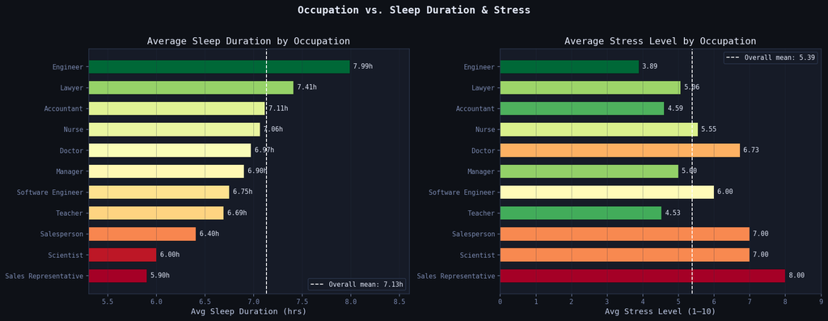

```
📊 Occupation Summary Table
```

| Occupation | Count | Avg_Sleep | Avg_Stress | Avg_Quality | Avg_Steps |
| --- | --- | --- | --- | --- | --- |
| Engineer | 63 | 7.99 | 3.89 | 8.41 | 5980.95 |
| Lawyer | 47 | 7.41 | 5.06 | 7.89 | 7661.70 |
| Accountant | 37 | 7.11 | 4.59 | 7.89 | 6881.08 |
| Nurse | 73 | 7.06 | 5.55 | 7.37 | 8057.53 |
| Doctor | 71 | 6.97 | 6.73 | 6.65 | 6808.45 |
| Manager | 1 | 6.90 | 5.00 | 7.00 | 5500.00 |
| Software Engineer | 4 | 6.75 | 6.00 | 6.50 | 5800.00 |
| Teacher | 40 | 6.69 | 4.53 | 6.98 | 5957.50 |
| Salesperson | 32 | 6.40 | 7.00 | 6.00 | 6000.00 |
| Scientist | 4 | 6.00 | 7.00 | 5.00 | 5350.00 |
| Sales Representative | 2 | 5.90 | 8.00 | 4.00 | 3000.00 |

```python
fig, axes = plt.subplots(1, 2, figsize=(16, 6))
fig.patch.set_facecolor('#0e1117')

occ_sleep = df.groupby('Occupation')['Sleep Duration'].mean().sort_values()
occ_stress = df.groupby('Occupation')['Stress Level'].mean().reindex(occ_sleep.index)

# Color bars by sleep duration
norm   = plt.Normalize(occ_sleep.min(), occ_sleep.max())
cmap   = plt.cm.RdYlGn
colors = [cmap(norm(v)) for v in occ_sleep]

# ── Sleep duration by occupation ──
ax = axes[0]
bars = ax.barh(occ_sleep.index, occ_sleep.values, color=colors,
               edgecolor='#0e1117', linewidth=0.5, height=0.65)
ax.set_xlabel('Avg Sleep Duration (hrs)')
ax.set_title('Average Sleep Duration by Occupation')
ax.axvline(df['Sleep Duration'].mean(), color='white', linestyle='--',
           linewidth=1.2, label=f"Overall mean: {df['Sleep Duration'].mean():.2f}h")
ax.legend()
ax.set_xlim(5.3, 8.6)
ax.grid(axis='x', alpha=0.4)
for bar, val in zip(bars, occ_sleep.values):
    ax.text(val + 0.04, bar.get_y() + bar.get_height()/2,
            f'{val:.2f}h', va='center', fontsize=9, color='#e2e8f8')

# ── Stress level by occupation ──
ax2 = axes[1]
stress_colors = [plt.cm.RdYlGn_r(norm2) for norm2 in
                 plt.Normalize(occ_stress.min(), occ_stress.max())(occ_stress.values)]
bars2 = ax2.barh(occ_stress.index, occ_stress.values, color=stress_colors,
                 edgecolor='#0e1117', linewidth=0.5, height=0.65)
ax2.set_xlabel('Avg Stress Level (1–10)')
ax2.set_title('Average Stress Level by Occupation')
ax2.axvline(df['Stress Level'].mean(), color='white', linestyle='--',
            linewidth=1.2, label=f"Overall mean: {df['Stress Level'].mean():.2f}")
ax2.legend()
ax2.set_xlim(0, 9)
ax2.grid(axis='x', alpha=0.4)
for bar, val in zip(bars2, occ_stress.values):
    ax2.text(val + 0.1, bar.get_y() + bar.get_height()/2,
             f'{val:.2f}', va='center', fontsize=9, color='#e2e8f8')

plt.suptitle('Occupation vs. Sleep Duration & Stress', fontsize=14,
             fontweight='bold', color='#e2e8f8', y=1.02)
plt.tight_layout()
plt.show()

# Print table
print("\n📊 Occupation Summary Table")
occ_summary = df.groupby('Occupation').agg(
    Count=('Sleep Duration','count'),
    Avg_Sleep=('Sleep Duration','mean'),
    Avg_Stress=('Stress Level','mean'),
    Avg_Quality=('Quality of Sleep','mean'),
    Avg_Steps=('Daily Steps','mean')
).round(2).sort_values('Avg_Sleep', ascending=False)
display(occ_summary)
```

## 😰 8. Stress Level vs. Sleep Quality (The Core Relationship)

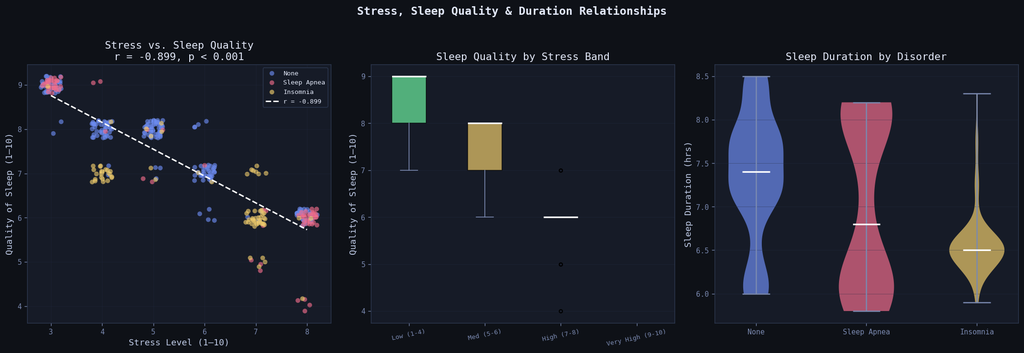

```python
fig, axes = plt.subplots(1, 3, figsize=(18, 6))
fig.patch.set_facecolor('#0e1117')

# ── Scatter: Stress vs Quality ──
ax = axes[0]
for disorder, color in PALETTE.items():
    if disorder not in ['None', 'Sleep Apnea', 'Insomnia']: continue
    sub = df[df['Sleep Disorder'] == disorder]
    jitter_x = sub['Stress Level']  + np.random.uniform(-0.2, 0.2, len(sub))
    jitter_y = sub['Quality of Sleep'] + np.random.uniform(-0.2, 0.2, len(sub))
    ax.scatter(jitter_x, jitter_y, c=color, alpha=0.65, s=35, label=disorder, edgecolors='none')

# Regression line
slope, intercept, r, p, se = stats.linregress(df['Stress Level'], df['Quality of Sleep'])
xs = np.linspace(df['Stress Level'].min(), df['Stress Level'].max(), 100)
ax.plot(xs, slope*xs + intercept, color='white', linewidth=1.8,
        linestyle='--', label=f'r = {r:.3f}')
ax.set_xlabel('Stress Level (1–10)')
ax.set_ylabel('Quality of Sleep (1–10)')
ax.set_title(f'Stress vs. Sleep Quality\nr = {r:.3f}, p < 0.001')
ax.legend(fontsize=8)
ax.grid(alpha=0.3)

# ── Box: Sleep Quality by Stress bucket ──
ax2 = axes[1]
df['Stress_Band'] = pd.cut(df['Stress Level'], bins=[0,4,6,8,10],
                            labels=['Low (1-4)','Med (5-6)','High (7-8)','Very High (9-10)'])
order = ['Low (1-4)', 'Med (5-6)', 'High (7-8)', 'Very High (9-10)']
band_colors = ['#6cef9f','#efcb6c','#ef9f6c','#ef6c8b']
bp = ax2.boxplot(
    [df[df['Stress_Band']==b]['Quality of Sleep'].dropna() for b in order],
    patch_artist=True,
    medianprops=dict(color='white', linewidth=2),
    whiskerprops=dict(color='#7a89b0'),
    capprops=dict(color='#7a89b0'),
    flierprops=dict(marker='o', color='#7a89b0', markersize=4, alpha=0.5)
)
for patch, color in zip(bp['boxes'], band_colors):
    patch.set_facecolor(color); patch.set_alpha(0.7)
ax2.set_xticklabels(order, rotation=12, fontsize=8)
ax2.set_ylabel('Quality of Sleep (1–10)')
ax2.set_title('Sleep Quality by Stress Band')
ax2.grid(axis='y', alpha=0.4)

# ── Violin: Sleep Duration by Disorder ──
ax3 = axes[2]
disorder_order = ['None', 'Sleep Apnea', 'Insomnia']
parts = ax3.violinplot(
    [df[df['Sleep Disorder']==d]['Sleep Duration'] for d in disorder_order],
    positions=range(len(disorder_order)),
    showmedians=True
)
for i, (pc, disorder) in enumerate(zip(parts['bodies'], disorder_order)):
    pc.set_facecolor(PALETTE[disorder]); pc.set_alpha(0.7)
parts['cmedians'].set_color('white'); parts['cmedians'].set_linewidth(2)
parts['cmins'].set_color('#7a89b0');   parts['cmaxes'].set_color('#7a89b0')
parts['cbars'].set_color('#7a89b0')
ax3.set_xticks(range(len(disorder_order)))
ax3.set_xticklabels(disorder_order)
ax3.set_ylabel('Sleep Duration (hrs)')
ax3.set_title('Sleep Duration by Disorder')
ax3.grid(axis='y', alpha=0.4)

plt.suptitle('Stress, Sleep Quality & Duration Relationships', fontsize=14,
             fontweight='bold', color='#e2e8f8', y=1.02)
plt.tight_layout()
plt.show()
```

## 🔗 9. Correlation Heatmap

```
🏆 Top 5 Strongest Correlations:
Feature A                    Feature B                           r
------------------------------------------------------------------
Stress Level                 Quality of Sleep              -0.899  ▼
Quality of Sleep             Sleep Duration                +0.883  ▲
Stress Level                 Sleep Duration                -0.811  ▼
Daily Steps                  Physical Activity Level       +0.773  ▲
Heart Rate                   Stress Level                  +0.670  ▲
```

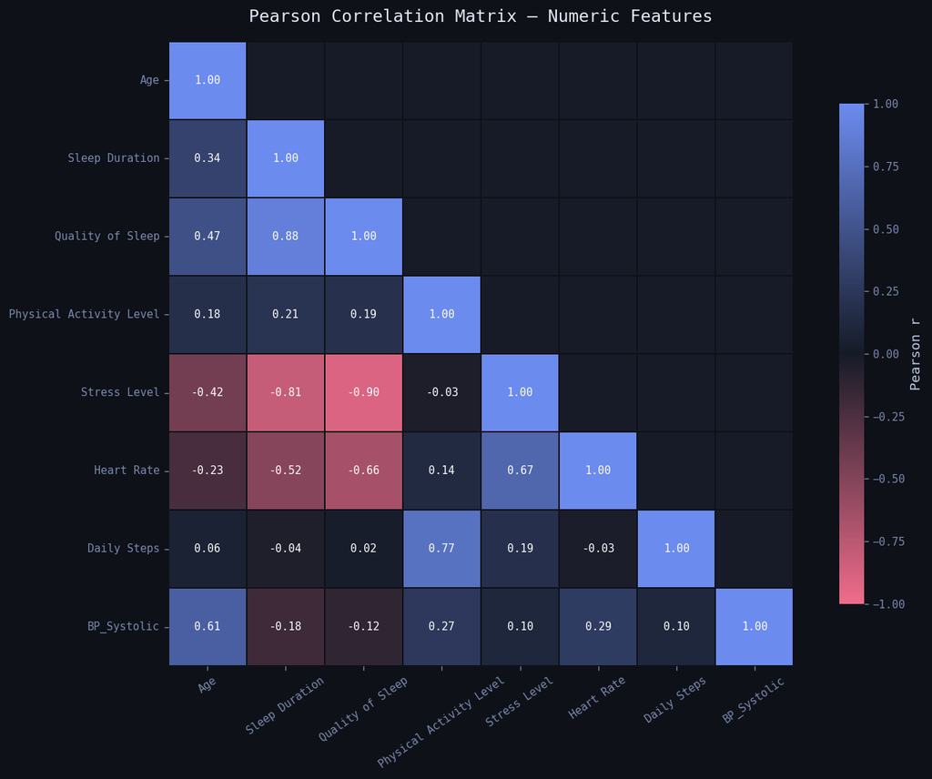

```python
fig, ax = plt.subplots(figsize=(12, 9))
fig.patch.set_facecolor('#0e1117')

num_df = df.select_dtypes(include='number').drop(columns=['BP_Diastolic'], errors='ignore')
corr   = num_df.corr()

# Custom diverging colormap: red → black → blue
cmap = LinearSegmentedColormap.from_list('rb', ['#ef6c8b','#161b27','#6c8bef'])

mask = np.zeros_like(corr, dtype=bool)
mask[np.triu_indices_from(mask, k=1)] = True   # show lower triangle + diagonal

sns.heatmap(
    corr,
    mask=mask,
    cmap=cmap,
    vmin=-1, vmax=1,
    annot=True, fmt='.2f',
    annot_kws={'size': 9, 'color': 'white'},
    linewidths=1, linecolor='#0e1117',
    square=True,
    cbar_kws={'label': 'Pearson r', 'shrink': 0.8},
    ax=ax
)

ax.set_title('Pearson Correlation Matrix — Numeric Features', pad=16, fontsize=14)
ax.tick_params(axis='x', rotation=35)
ax.tick_params(axis='y', rotation=0)

# Highlight strongest pairs as annotations
top_pairs = []
for i in range(len(corr.columns)):
    for j in range(i):
        top_pairs.append((abs(corr.iloc[i,j]), corr.columns[i], corr.columns[j], corr.iloc[i,j]))
top_pairs.sort(reverse=True)

print("\n🏆 Top 5 Strongest Correlations:")
print(f"{'Feature A':<28} {'Feature B':<28} {'r':>8}")
print("-" * 66)
for _, a, b, r in top_pairs[:5]:
    direction = '▲' if r > 0 else '▼'
    print(f"{a:<28} {b:<28} {r:>+7.3f}  {direction}")

plt.tight_layout()
plt.show()
```

## 🏃 10. Physical Activity & Daily Steps

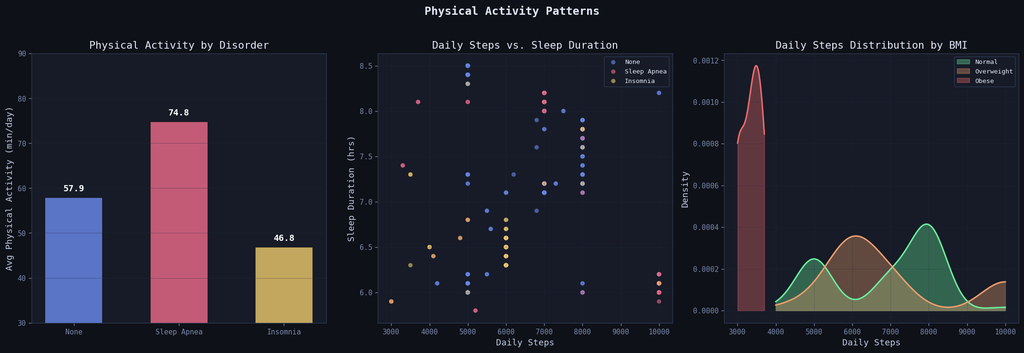

```python
fig, axes = plt.subplots(1, 3, figsize=(18, 6))
fig.patch.set_facecolor('#0e1117')

# ── Activity by disorder ──
ax = axes[0]
act = df.groupby('Sleep Disorder')['Physical Activity Level'].mean().reindex(['None','Sleep Apnea','Insomnia'])
colors_ = [PALETTE[d] for d in act.index]
bars = ax.bar(act.index, act.values, color=colors_, alpha=0.8, edgecolor='#0e1117', width=0.55)
ax.set_ylabel('Avg Physical Activity (min/day)')
ax.set_title('Physical Activity by Disorder')
ax.grid(axis='y', alpha=0.4)
ax.set_ylim(30, 90)
for bar, val in zip(bars, act.values):
    ax.text(bar.get_x() + bar.get_width()/2, val + 1,
            f'{val:.1f}', ha='center', va='bottom', fontsize=11, color='white', fontweight='bold')

# ── Steps vs Sleep Duration scatter ──
ax2 = axes[1]
for disorder, color in zip(['None','Sleep Apnea','Insomnia'], [PALETTE['None'], PALETTE['Sleep Apnea'], PALETTE['Insomnia']]):
    sub = df[df['Sleep Disorder'] == disorder]
    ax2.scatter(sub['Daily Steps'], sub['Sleep Duration'],
                c=color, alpha=0.6, s=30, label=disorder, edgecolors='none')
ax2.set_xlabel('Daily Steps')
ax2.set_ylabel('Sleep Duration (hrs)')
ax2.set_title('Daily Steps vs. Sleep Duration')
ax2.legend(fontsize=8)
ax2.grid(alpha=0.3)

# ── Steps distribution by BMI ──
ax3 = axes[2]
for bmi, color in zip(['Normal','Overweight','Obese'], [PALETTE['Normal'], PALETTE['Overweight'], PALETTE['Obese']]):
    data = df[df['BMI Category'] == bmi]['Daily Steps']
    kde_x = np.linspace(data.min(), data.max(), 200)
    kde   = stats.gaussian_kde(data)
    ax3.fill_between(kde_x, kde(kde_x), alpha=0.35, color=color, label=bmi)
    ax3.plot(kde_x, kde(kde_x), color=color, linewidth=1.8)
ax3.set_xlabel('Daily Steps')
ax3.set_ylabel('Density')
ax3.set_title('Daily Steps Distribution by BMI')
ax3.legend(fontsize=8)
ax3.grid(alpha=0.3)

plt.suptitle('Physical Activity Patterns', fontsize=14,
             fontweight='bold', color='#e2e8f8', y=1.02)
plt.tight_layout()
plt.show()
```

## 🩺 11. Age, Heart Rate & Blood Pressure

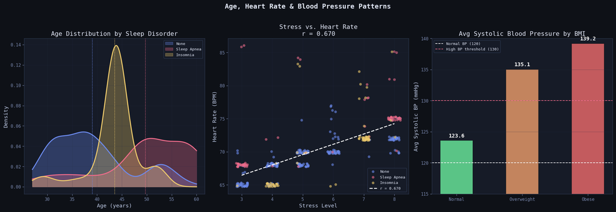

```python
fig, axes = plt.subplots(1, 3, figsize=(18, 6))
fig.patch.set_facecolor('#0e1117')

# ── Age distribution by disorder ──
ax = axes[0]
for disorder, color in zip(['None','Sleep Apnea','Insomnia'],
                            [PALETTE['None'], PALETTE['Sleep Apnea'], PALETTE['Insomnia']]):
    data = df[df['Sleep Disorder'] == disorder]['Age']
    kde_x = np.linspace(27, 60, 200)
    kde = stats.gaussian_kde(data)
    ax.fill_between(kde_x, kde(kde_x), alpha=0.3, color=color, label=disorder)
    ax.plot(kde_x, kde(kde_x), color=color, linewidth=2)
    ax.axvline(data.mean(), color=color, linestyle=':', linewidth=1.2)
ax.set_xlabel('Age (years)')
ax.set_ylabel('Density')
ax.set_title('Age Distribution by Sleep Disorder')
ax.legend(fontsize=8)
ax.grid(alpha=0.3)

# ── Heart Rate vs Stress ──
ax2 = axes[1]
for disorder, color in zip(['None','Sleep Apnea','Insomnia'],
                            [PALETTE['None'], PALETTE['Sleep Apnea'], PALETTE['Insomnia']]):
    sub = df[df['Sleep Disorder'] == disorder]
    ax2.scatter(sub['Stress Level'] + np.random.uniform(-0.2,0.2,len(sub)),
                sub['Heart Rate']   + np.random.uniform(-0.3,0.3,len(sub)),
                c=color, alpha=0.6, s=30, label=disorder, edgecolors='none')
slope, intercept, r, p, _ = stats.linregress(df['Stress Level'], df['Heart Rate'])
xs = np.linspace(df['Stress Level'].min(), df['Stress Level'].max(), 100)
ax2.plot(xs, slope*xs + intercept, color='white', linewidth=1.8,
         linestyle='--', label=f'r = {r:.3f}')
ax2.set_xlabel('Stress Level')
ax2.set_ylabel('Heart Rate (BPM)')
ax2.set_title(f'Stress vs. Heart Rate\nr = {r:.3f}')
ax2.legend(fontsize=8)
ax2.grid(alpha=0.3)

# ── BP Systolic by BMI ──
ax3 = axes[2]
bp_bmi = df.groupby('BMI Category')['BP_Systolic'].mean().reindex(['Normal','Overweight','Obese'])
colors_ = [PALETTE['Normal'], PALETTE['Overweight'], PALETTE['Obese']]
bars = ax3.bar(bp_bmi.index, bp_bmi.values, color=colors_, alpha=0.8,
               edgecolor='#0e1117', width=0.5)
ax3.axhline(120, color='white', linestyle='--', linewidth=1.2, label='Normal BP (120)')
ax3.axhline(130, color='#ef6c8b', linestyle='--', linewidth=1.2, label='High BP threshold (130)')
ax3.set_ylabel('Avg Systolic BP (mmHg)')
ax3.set_title('Avg Systolic Blood Pressure by BMI')
ax3.legend(fontsize=8)
ax3.grid(axis='y', alpha=0.4)
ax3.set_ylim(115, 140)
for bar, val in zip(bars, bp_bmi.values):
    ax3.text(bar.get_x() + bar.get_width()/2, val + 0.3,
             f'{val:.1f}', ha='center', va='bottom', fontsize=11, color='white', fontweight='bold')

plt.suptitle('Age, Heart Rate & Blood Pressure Patterns', fontsize=14,
             fontweight='bold', color='#e2e8f8', y=1.02)
plt.tight_layout()
plt.show()
```

## 🔀 12. Multivariate Pairplot

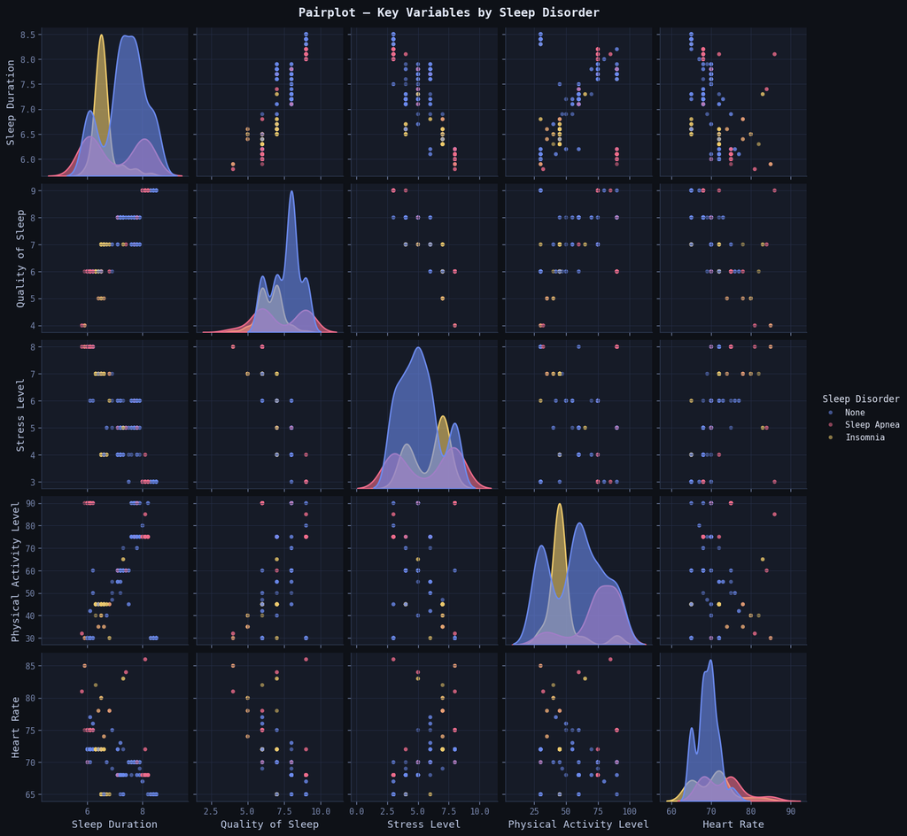

```python
# Pairplot on key variables, colored by Sleep Disorder
pair_cols = ['Sleep Duration', 'Quality of Sleep', 'Stress Level',
             'Physical Activity Level', 'Heart Rate', 'Sleep Disorder']

pair_df = df[pair_cols].copy()

g = sns.pairplot(
    pair_df,
    hue='Sleep Disorder',
    palette={'None': PALETTE['None'], 'Sleep Apnea': PALETTE['Sleep Apnea'], 'Insomnia': PALETTE['Insomnia']},
    plot_kws={'alpha': 0.55, 's': 18, 'edgecolor': 'none'},
    diag_kind='kde',
    diag_kws={'alpha': 0.6, 'linewidth': 1.5}
)

g.figure.patch.set_facecolor('#0e1117')
for ax_ in g.axes.flat:
    if ax_ is not None:
        ax_.set_facecolor('#161b27')
        ax_.grid(color='#252d45', linewidth=0.5)
        for spine in ax_.spines.values():
            spine.set_edgecolor('#2e3a52')

g.figure.suptitle('Pairplot — Key Variables by Sleep Disorder',
                  y=1.01, fontsize=13, color='#e2e8f8', fontweight='bold')
plt.show()
```

## 📐 13. Statistical Significance Tests

```python
from scipy.stats import kruskal, mannwhitneyu, chi2_contingency

print("=" * 65)
print("  STATISTICAL TESTS")
print("=" * 65)

# ── Kruskal-Wallis: Sleep Duration across disorder groups ──
groups = [df[df['Sleep Disorder']==d]['Sleep Duration'] for d in ['None','Sleep Apnea','Insomnia']]
H, p = kruskal(*groups)
print(f"\n  Kruskal-Wallis: Sleep Duration across Disorder groups")
print(f"    H = {H:.3f},  p = {p:.4e}  {'✅ Significant' if p < 0.05 else '❌ Not significant'}")

# ── Kruskal-Wallis: Stress Level across disorder groups ──
groups_s = [df[df['Sleep Disorder']==d]['Stress Level'] for d in ['None','Sleep Apnea','Insomnia']]
H2, p2 = kruskal(*groups_s)
print(f"\n  Kruskal-Wallis: Stress Level across Disorder groups")
print(f"    H = {H2:.3f},  p = {p2:.4e}  {'✅ Significant' if p2 < 0.05 else '❌ Not significant'}")

# ── Chi-square: BMI × Sleep Disorder ──
ct = pd.crosstab(df['BMI Category'], df['Sleep Disorder'])
chi2, p3, dof, expected = chi2_contingency(ct)
print(f"\n  Chi-Square: BMI Category × Sleep Disorder")
print(f"    χ² = {chi2:.3f},  df = {dof},  p = {p3:.4e}  {'✅ Significant' if p3 < 0.05 else '❌ Not significant'}")

# ── Chi-square: Gender × Sleep Disorder ──
ct2 = pd.crosstab(df['Gender'], df['Sleep Disorder'])
chi2b, p4, dof2, _ = chi2_contingency(ct2)
print(f"\n  Chi-Square: Gender × Sleep Disorder")
print(f"    χ² = {chi2b:.3f},  df = {dof2},  p = {p4:.4e}  {'✅ Significant' if p4 < 0.05 else '❌ Not significant'}")

# ── Mann-Whitney: Physical Activity — Apnea vs Insomnia ──
apnea_act  = df[df['Sleep Disorder']=='Sleep Apnea']['Physical Activity Level']
ins_act    = df[df['Sleep Disorder']=='Insomnia']['Physical Activity Level']
U, p5 = mannwhitneyu(apnea_act, ins_act, alternative='two-sided')
print(f"\n  Mann-Whitney U: Physical Activity — Apnea vs. Insomnia")
print(f"    U = {U:.1f},  p = {p5:.4e}  {'✅ Significant' if p5 < 0.05 else '❌ Not significant'}")

print("\n" + "=" * 65)
print("  All tests use α = 0.05")
print("=" * 65)
```

```
=================================================================
  STATISTICAL TESTS
=================================================================

  Kruskal-Wallis: Sleep Duration across Disorder groups
    H = 43.899,  p = 2.9342e-10  ✅ Significant

  Kruskal-Wallis: Stress Level across Disorder groups
    H = 10.042,  p = 6.5974e-03  ✅ Significant

  Chi-Square: BMI Category × Sleep Disorder
    χ² = 245.665,  df = 4,  p = 5.5884e-52  ✅ Significant

  Chi-Square: Gender × Sleep Disorder
    χ² = 54.306,  df = 2,  p = 1.6129e-12  ✅ Significant

  Mann-Whitney U: Physical Activity — Apnea vs. Insomnia
    U = 5095.5,  p = 5.3989e-15  ✅ Significant

=================================================================
  All tests use α = 0.05
=================================================================
```

## 📋 14. Key Findings & Conclusions

### 🔑 Finding 1 — Stress is the Master Predictor

Stress Level shows the strongest correlations in the entire dataset:

- **r = −0.81** with Sleep Duration
- **r = −0.90** with Quality of Sleep

Any predictive model for sleep disorder risk should treat Stress Level as a primary feature.

### 🔑 Finding 2 — BMI is a Near-Perfect Disorder Stratifier

| BMI Category | % No Disorder | % Sleep Apnea | % Insomnia |
| --- | --- | --- | --- |
| Normal | ~93% | ~3% | ~4% |
| Overweight | ~13% | ~44% | ~43% |
| Obese | ~0% | ~60% | ~40% |

The association is statistically significant (χ² test, p < 0.001).

### 🔑 Finding 3 — Occupation Drives Sleep Gaps

Engineers average **8.0h** vs. Sales Representatives at **5.9h** — a 2-hour gap driven primarily by occupational stress profiles.

### 🔑 Finding 4 — Gender × Sleep Apnea Asymmetry

**86% of Sleep Apnea cases are female**, likely reflecting the occupational composition of the dataset (nurses dominate and skew female). A stratified analysis controlling for occupation is recommended before drawing clinical conclusions.

### 🔑 Finding 5 — Heart Rate as a Passive Proxy

Heart Rate correlates **r = +0.67** with Stress Level and **r = −0.66** with Sleep Quality. As a passively-measurable wearable metric, heart rate could serve as a real-time sleep quality proxy.

### ⚠️ Dataset Limitations

- **Small N = 374** with heavy occupational class imbalance (1 Manager vs 73 Nurses)
- Systolic BP range is narrow (115–142 mmHg), suggesting the data may be synthetic or pre-screened
- No longitudinal dimension — all observations are cross-sectional
- Treat all findings as **directional**, not causal